# Practical Machine Learning Quiz 4 Question 2

Rich Seiter

Monday, June 23, 2014

I found this quiz question very frustrating. The answers I obtained did not agree with the choices (see [Quiz 4 - Model Stacking, answer seems wrong](https://class.coursera.org/predmachlearn-002/forum/thread?thread_id=137)) and I think the stacking technique used was suboptimal for a classification problem (why not use probabilities instead of predictions?).

To salvage something from this experience I decided to use this as an opportunity to create an example using caretEnsemble. First install (from Github, if necessary) and load the package. This installs the Dev package to get tests and also runs those tests.

The source code for this file resides in CaretEnsembleExample.Rmd and the resulting HTML can be viewed at http://rseiter.github.io/PracticalMLProject/CaretEnsembleExample.html

```r
library(caret)

if(!require(caretEnsemble)){
  library(devtools)
  library(testthat)
  #install_github('zachmayer/caretEnsemble') #Master branch (currently has no tests)
  install_github('zachmayer/caretEnsemble', ref = 'Dev') #Dev branch
  test_package('caretEnsemble') #Run tests
}
```

The initial setup and model training is similar to the quiz question (note that this does NOT provide an answer, the seeds are different) except for the addition of a trainControl whuch runs 10-fold CV with the same resampling indexes (required for caretEnsemble to work correctly).

```r
set.seed(123)
library(AppliedPredictiveModeling)
data(AlzheimerDisease)
adData = data.frame(diagnosis,predictors)
inTrain = createDataPartition(adData$diagnosis, p = 3/4)[[1]]
training = adData[ inTrain,]
testing = adData[-inTrain,]

set.seed(123)
folds=10
repeats=1
# Try using ROC (AUC) as metric since that is what caretEnsemble uses
trainMetric = "ROC" # Classification, required for some two class analyses
# Use multiClassSummary to get more complete performance information
# setwd("~/Education/Coursera - Practical Machine Learning/Course Project/PracticalMLProject")
source("multiClassSummary.R")
trainSummary <- multiClassSummary
fitControl <-
  trainControl(method = "cv",
               number = folds, # 10 is default
               repeats = repeats,
               index=createMultiFolds(training$diagnosis, k=folds, times=repeats), # For caretEnsemble, make the resampling indexes all the same.
               savePredictions = TRUE,
               classProbs = TRUE, # Needed for twoClassSummary
               summaryFunction = trainSummary
)

modelFitQ2rf  <- train(diagnosis ~ ., training, method="rf", metric=trainMetric,
                       trControl = fitControl)
modelFitQ2gbm <- train(diagnosis ~ ., training, method="gbm", metric=trainMetric,
                       trControl = fitControl, verbose=FALSE)
modelFitQ2lda <- train(diagnosis ~ ., training, method="lda", metric=trainMetric,
                       trControl = fitControl)
```

Now look at the performance results for the base models.

```r
# Check CV results
# These are too verbose with multiClassSummary
# modelFitQ2rf
# modelFitQ2gbm
# modelFitQ2lda
getTrainPerf(modelFitQ2rf)
```

```
##   TrainROC TrainSensitivity TrainSpecificity TrainAccuracy TrainKappa
## 1   0.8639           0.6071           0.9447        0.8528     0.5928
##   TrainlogLoss TrainAccuracyLower TrainAccuracyUpper TrainAccuracyPValue
## 1       0.3936             0.6618             0.9528              0.1849
##   TrainMcnemarPValue TrainPos_Pred_Value TrainNeg_Pred_Value
## 1             0.6538              0.8231              0.8669
##   TrainDetection_Rate TrainBalanced_Accuracy method
## 1              0.1677                 0.7759     rf
```

```r
getTrainPerf(modelFitQ2gbm)
```

```
##   TrainROC TrainSensitivity TrainSpecificity TrainAccuracy TrainKappa
## 1   0.8885           0.6476           0.9336        0.8566     0.6136
##   TrainlogLoss TrainAccuracyLower TrainAccuracyUpper TrainAccuracyPValue
## 1       0.3792             0.6647             0.9565              0.1773
##   TrainMcnemarPValue TrainPos_Pred_Value TrainNeg_Pred_Value
## 1              0.708              0.8118              0.8787
##   TrainDetection_Rate TrainBalanced_Accuracy method
## 1              0.1795                 0.7906    gbm
```

```r
getTrainPerf(modelFitQ2lda)
```

```
##   TrainROC TrainSensitivity TrainSpecificity TrainAccuracy TrainKappa
## 1   0.8286           0.6976           0.7696        0.7488     0.4287
##   TrainlogLoss TrainAccuracyLower TrainAccuracyUpper TrainAccuracyPValue
## 1        1.699             0.5388             0.8969              0.4917
##   TrainMcnemarPValue TrainPos_Pred_Value TrainNeg_Pred_Value
## 1              0.566              0.5538              0.8719
##   TrainDetection_Rate TrainBalanced_Accuracy method
## 1              0.1912                 0.7336    lda
```

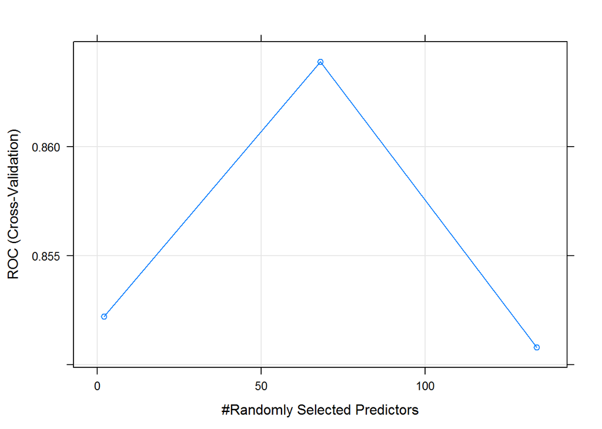

```r
# Look at model parameter optimization
plot(modelFitQ2rf)
```

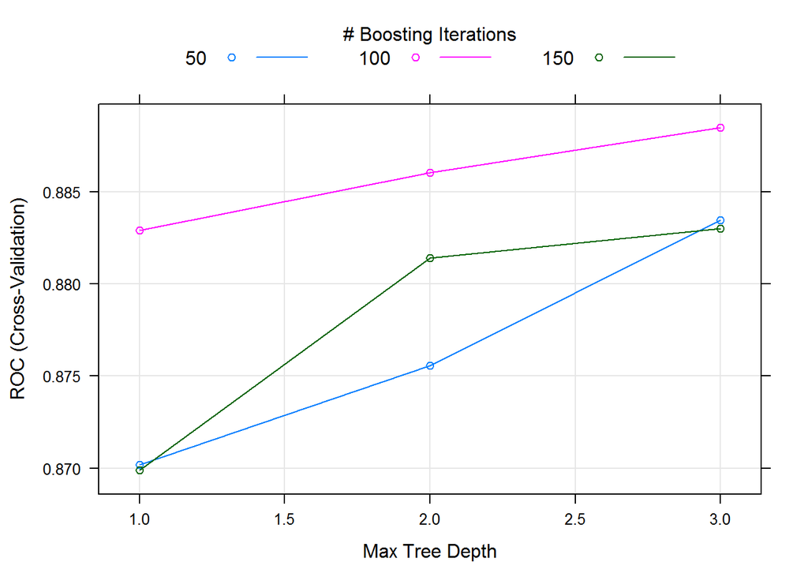

```r
plot(modelFitQ2gbm)
```

```r
# Check test results
testPredQ2rf <-  predict(modelFitQ2rf,  newdata=testing)
testPredQ2gbm <- predict(modelFitQ2gbm, newdata=testing)
testPredQ2lda <- predict(modelFitQ2lda, newdata=testing)
confusionMatrix(testPredQ2rf,  testing$diagnosis)
```

```
## Confusion Matrix and Statistics
##
##           Reference
## Prediction Impaired Control
##   Impaired       10       2
##   Control        12      58
##
##                Accuracy : 0.829
##                  95% CI : (0.73, 0.903)
##     No Information Rate : 0.732
##     P-Value [Acc > NIR] : 0.0268
##
##                   Kappa : 0.492
##  Mcnemar's Test P-Value : 0.0162
##
##             Sensitivity : 0.455
##             Specificity : 0.967
##          Pos Pred Value : 0.833
##          Neg Pred Value : 0.829
##              Prevalence : 0.268
##          Detection Rate : 0.122
##    Detection Prevalence : 0.146
##       Balanced Accuracy : 0.711
##
##        'Positive' Class : Impaired
##
```

```r
confusionMatrix(testPredQ2gbm, testing$diagnosis)
```

```
## Confusion Matrix and Statistics
##
##           Reference
## Prediction Impaired Control
##   Impaired       12       4
##   Control        10      56
##
##                Accuracy : 0.829
##                  95% CI : (0.73, 0.903)
##     No Information Rate : 0.732
##     P-Value [Acc > NIR] : 0.0268
##
##                   Kappa : 0.524
##  Mcnemar's Test P-Value : 0.1814
##
##             Sensitivity : 0.545
##             Specificity : 0.933
##          Pos Pred Value : 0.750
##          Neg Pred Value : 0.848
##              Prevalence : 0.268
##          Detection Rate : 0.146
##    Detection Prevalence : 0.195
##       Balanced Accuracy : 0.739
##
##        'Positive' Class : Impaired
##
```

```r
confusionMatrix(testPredQ2lda, testing$diagnosis)
```

```
## Confusion Matrix and Statistics
##
##           Reference
## Prediction Impaired Control
##   Impaired       13       8
##   Control         9      52
##
##                Accuracy : 0.793
##                  95% CI : (0.689, 0.874)
##     No Information Rate : 0.732
##     P-Value [Acc > NIR] : 0.13
##
##                   Kappa : 0.464
##  Mcnemar's Test P-Value : 1.00
##
##             Sensitivity : 0.591
##             Specificity : 0.867
##          Pos Pred Value : 0.619
##          Neg Pred Value : 0.852
##              Prevalence : 0.268
##          Detection Rate : 0.159
##    Detection Prevalence : 0.256
##       Balanced Accuracy : 0.729
##
##        'Positive' Class : Impaired
##
```

Now create a caretEnsemble model using the RF, GBM, and LDA base models. This creates a simple weighted blend. See ?caretEnsemble (including paper reference at the end) for more information.

```r
# First create a list of models to use in the ensemble (naming prevents later errors)
models <- list(rf=modelFitQ2rf, gbm=modelFitQ2gbm, lda=modelFitQ2lda)

# By default caretEnsemble optimizes AUC for classification,
# which optFun can I use to change this?
caretEns <- caretEnsemble(models)
```

Now look at the performance results for the ensemble.

```r
summary(caretEns)
```

```
## The following models were ensembled: rf, gbm, lda
## They were weighted:
## 0.2 0.75 0.05
## The resulting AUC is: 0.9001
## The fit for each individual model on the AUC is:
##   method metric metricSD
## 1     rf 0.8639  0.09917
## 2    gbm 0.8885  0.10585
## 3    lda 0.8286  0.07832
```

```r
testPredQ2ens <- predict(caretEns, newdata=testing)
```

```
## Predictions being made only for cases with complete data
```

```r
# To look at base model predictions all together:
# object <- caretEns
# preds <- multiPredict(object$models, type, newdata=testing)

# Is there a cleaner way to do this?
confusionMatrix(testPredQ2ens > 0.5, testing$diagnosis == "Control")
```

```
## Confusion Matrix and Statistics
##
##           Reference
## Prediction FALSE TRUE
##      FALSE    12    4
##      TRUE     10   56
##
##                Accuracy : 0.829
##                  95% CI : (0.73, 0.903)
##     No Information Rate : 0.732
##     P-Value [Acc > NIR] : 0.0268
##
##                   Kappa : 0.524
##  Mcnemar's Test P-Value : 0.1814
##
##             Sensitivity : 0.545
##             Specificity : 0.933
##          Pos Pred Value : 0.750
##          Neg Pred Value : 0.848
##              Prevalence : 0.268
##          Detection Rate : 0.146
##    Detection Prevalence : 0.195
##       Balanced Accuracy : 0.739
##
##        'Positive' Class : FALSE
##
```

Now look at the ROC plots for the base models and ensemble.

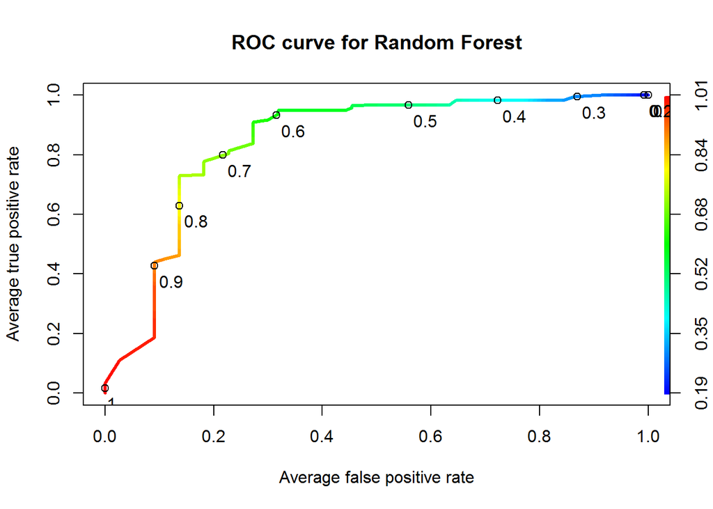

```r
# Turn caching off here since it keeps giving error
require(ROCR) # ROC plots

# First the base models.  This requires probabilities.
testPredQ2rfprob <-  predict(modelFitQ2rf,  newdata=testing, type="prob")[2]
testPredQ2gbmprob <- predict(modelFitQ2gbm, newdata=testing, type="prob")[2]
testPredQ2ldaprob <- predict(modelFitQ2lda, newdata=testing, type="prob")[2]

predrf <- prediction(predictions = testPredQ2rfprob,
                  labels = testing$diagnosis,
                  label.ordering = levels(testing$diagnosis))
perfrf <- performance(predrf, "tpr", "fpr") # standard ROC curve, see demo for more
plot(perfrf, avg= "threshold", colorize=T, lwd= 3,
     print.cutoffs.at=seq(0,1,by=0.1), text.adj=c(-0.2,1.7), # Add threshold values
     main=paste("ROC curve for Random Forest"))
```

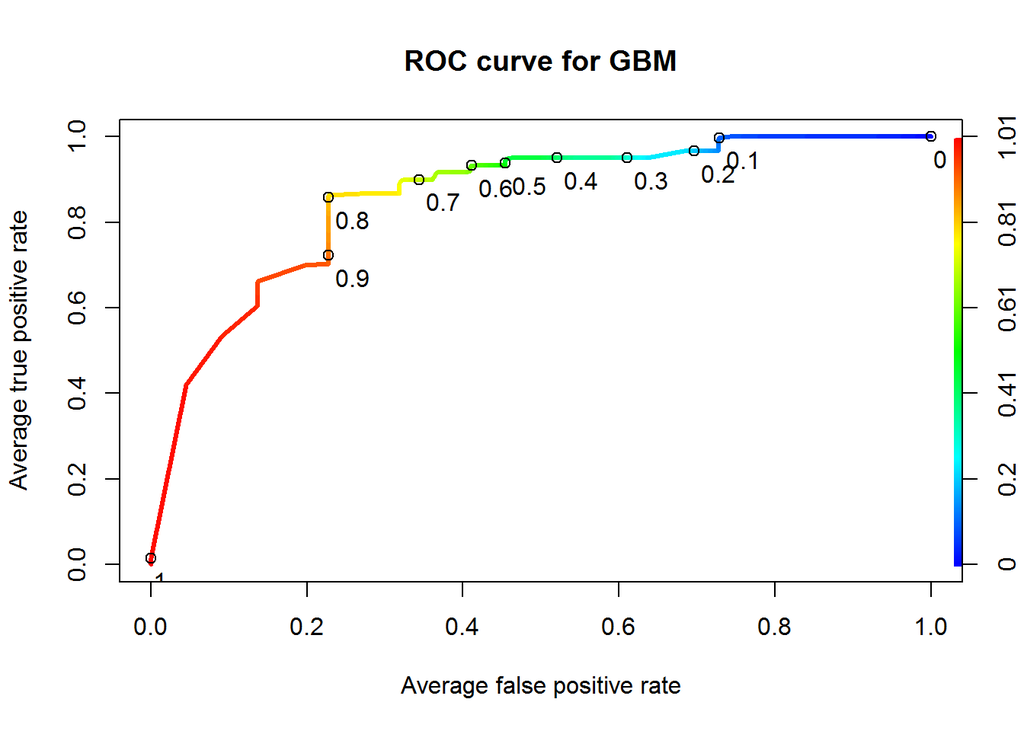

```r
predgbm <- prediction(predictions = testPredQ2gbmprob,
                  labels = testing$diagnosis,
                  label.ordering = levels(testing$diagnosis))
perfgbm <- performance(predgbm, "tpr", "fpr") # standard ROC curve, see demo for more
plot(perfgbm, avg= "threshold", colorize=T, lwd= 3,
     print.cutoffs.at=seq(0,1,by=0.1), text.adj=c(-0.2,1.7), # Add threshold values
     main=paste("ROC curve for GBM"))
```

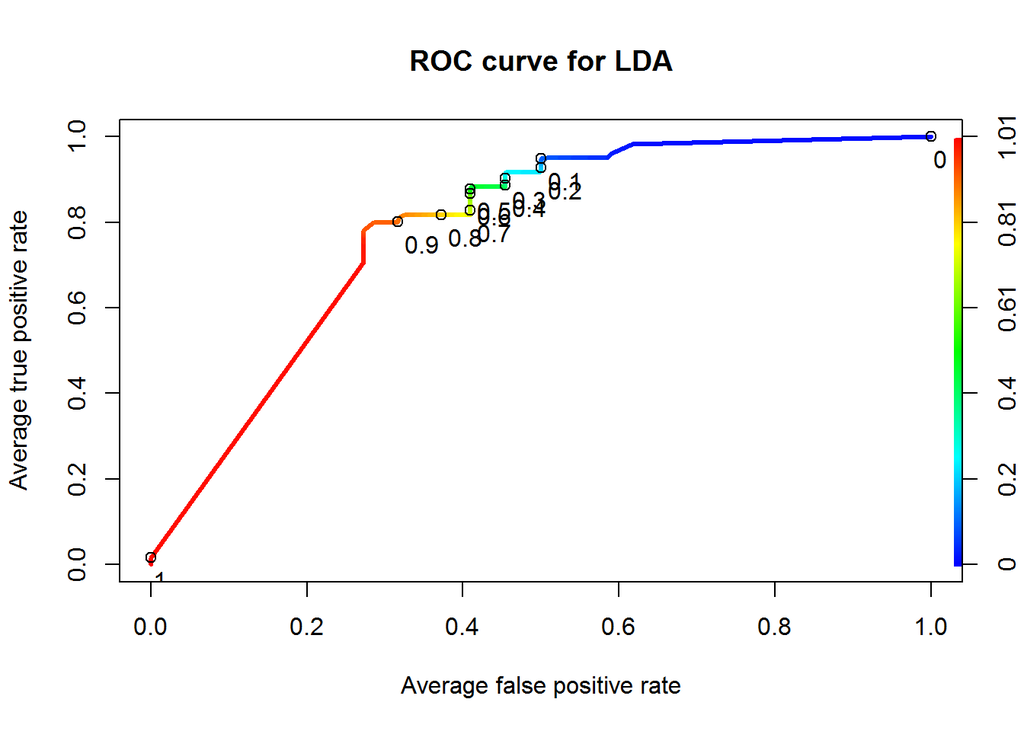

```r
predlda <- prediction(predictions = testPredQ2ldaprob,
                  labels = testing$diagnosis,
                  label.ordering = levels(testing$diagnosis))
perflda <- performance(predlda, "tpr", "fpr") # standard ROC curve, see demo for more
plot(perflda, avg= "threshold", colorize=T, lwd= 3,
     print.cutoffs.at=seq(0,1,by=0.1), text.adj=c(-0.2,1.7), # Add threshold values
     main=paste("ROC curve for LDA"))
```

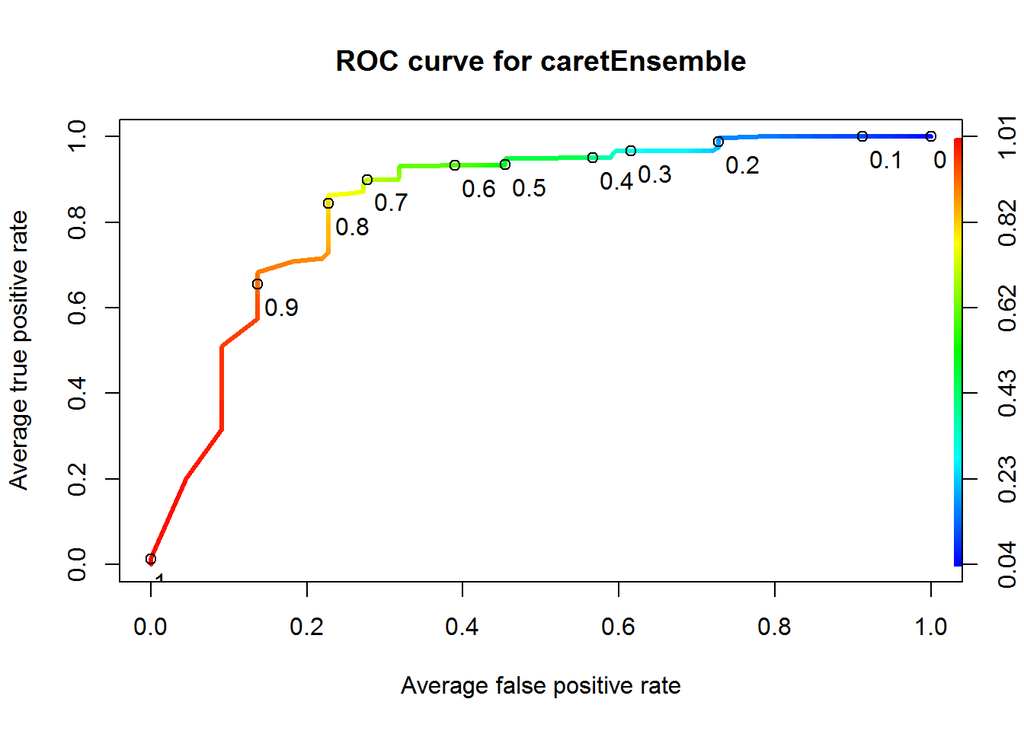

```r
predens <- prediction(predictions = testPredQ2ens,
                  labels = testing$diagnosis,
                  label.ordering = levels(testing$diagnosis))
perfens <- performance(predens, "tpr", "fpr") # standard ROC curve, see demo for more
plot(perfens, avg= "threshold", colorize=T, lwd= 3,
     print.cutoffs.at=seq(0,1,by=0.1), text.adj=c(-0.2,1.7), # Add threshold values
     main=paste("ROC curve for caretEnsemble"))
```

Now create a caretStack model using rpart with the RF, GBM, and LDA base models. See ?caretStack (including paper reference at the end) for more information.

Tried rpart, glm, and rf.

```r
caretSt <- caretStack(models, method='rpart', metric=trainMetric,
                      trControl=trainControl(method='cv',
                                             classProbs = TRUE, # Needed for twoClassSummary
                                             summaryFunction = trainSummary
                                             ))
```

Now look at the performance results for the stack.

```r
summary(caretSt)
```

```
##           Length Class      Mode
## models     3     -none-     list
## ens_model 19     train      list
## error     29     data.frame list
```

```r
# In contrast to caretEnsemble, caretStack requires "prob" to compute probabilities
testPredQ2st <- predict(caretSt, newdata=testing)
# To look at base model predictions all together:
# object <- caretSt
# preds <- multiPredict(object$models, type, newdata=testing)

confusionMatrix(testPredQ2st, testing$diagnosis)
```

```
## Confusion Matrix and Statistics
##
##           Reference
## Prediction Impaired Control
##   Impaired       15       6
##   Control         7      54
##
##                Accuracy : 0.841
##                  95% CI : (0.744, 0.913)
##     No Information Rate : 0.732
##     P-Value [Acc > NIR] : 0.0137
##
##                   Kappa : 0.59
##  Mcnemar's Test P-Value : 1.0000
##
##             Sensitivity : 0.682
##             Specificity : 0.900
##          Pos Pred Value : 0.714
##          Neg Pred Value : 0.885
##              Prevalence : 0.268
##          Detection Rate : 0.183
##    Detection Prevalence : 0.256
##       Balanced Accuracy : 0.791
##
##        'Positive' Class : Impaired
##
```

```r
#caretSt$ens_model
getTrainPerf(caretSt$ens_model)
```

```
##   TrainROC TrainSensitivity TrainSpecificity TrainAccuracy TrainKappa
## 1   0.8053           0.7095           0.9012        0.8486     0.6218
##   TrainlogLoss TrainAccuracyLower TrainAccuracyUpper TrainAccuracyPValue
## 1        0.415             0.6543             0.9534              0.1977
##   TrainMcnemarPValue TrainPos_Pred_Value TrainNeg_Pred_Value
## 1             0.6326               0.781              0.8944
##   TrainDetection_Rate TrainBalanced_Accuracy method
## 1              0.1953                 0.8053  rpart
```

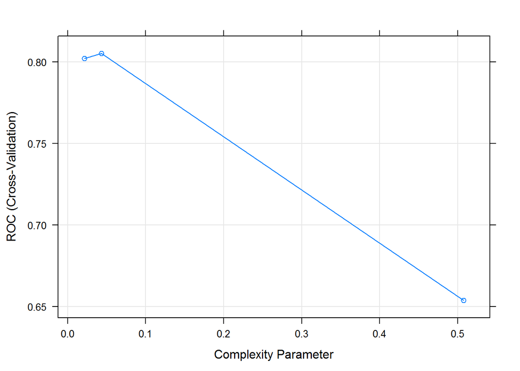

```r
plot(caretSt$ens_model)
```

```r
caretSt$ens_model$finalModel
```

```
## n= 251
##
## node), split, n, loss, yval, (yprob)
##       * denotes terminal node
##
## 1) root 251 69 Control (0.27490 0.72510)
##   2) gbm< 0.689 69 17 Impaired (0.75362 0.24638) *
##   3) gbm>=0.689 182 17 Control (0.09341 0.90659) *
```

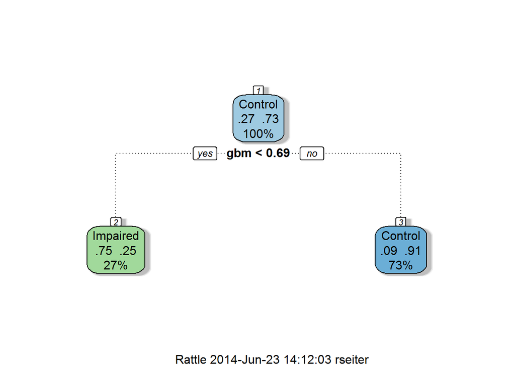

```r
library(rattle)
fancyRpartPlot(caretSt$ens_model$finalModel)
```